# Stats Inference Project

Michael Pearson

August 13, 2016

## Overview

I will compare the theoretical and simulated means and standard deviations of a large set of samples of the random exponential distribution.

## Simulations

```r
set.seed(500)
library(matrixStats)
## create a matrix of 1000 rows and 40 columms - with each row generated by a random exponential distribution of 40 values with a mean and standard deviate of 5 (1/0.2)
trippy <- matrix(data = 1, nrow = 1000, ncol = 40)
for (i in 1:1000){
  trippy[i,] <- rexp(40, 0.2)
}
## get the means of each row of exponential randoms
meanz <- rowMeans(trippy)
## get sd and var of each row
sdz <- rowSds(trippy)
varz <- rowVars(trippy)
## find the mean, variance and sd of the means of each row
meanit <- mean(meanz)
varmeans <- var(meanz)
sdomeans <- sd(meanz)
expectedsd <- 1/(0.2*sqrt(40))
## now for the mean of the standard deviation and its standard deviation
meansd <- mean(sdz)
sdzsd <- sd(sdz)
vart <- var(varz)
```

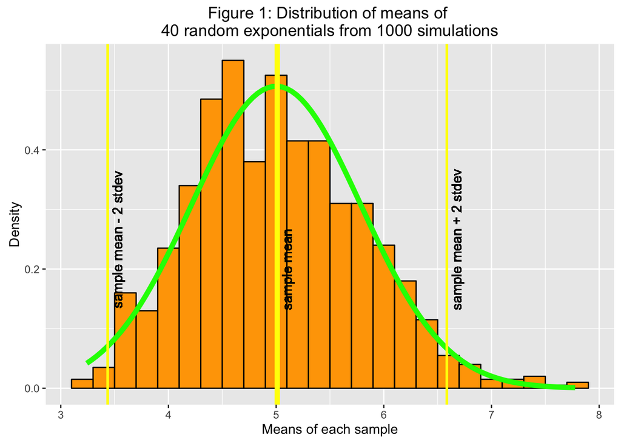

## Sample Mean versus Theoretical Mean:

The mean of the 1000 simulations was **5.0105617** as compared to the theoretical expected value of **5**.

The standard error of the means was **0.7874779**. We expected this to be 5 divided by the square root of 40: **0.7905694**. The difference between the inferred standard error and the theoretical is **-0.0030915**. So this was a good confirmation of our idea that the simulated values would be close to the theoretical ones.

The figure above has a normal distribution (in green) overlaid with the simulated results, to help given an idea of how well the data fits the theoretical expectations.

## Testing the hypothesis that the mean is 5

We can test the hypothesis that the mean of the simulated means is 5 by using a t test. The p-value we get for the null hypothesis (mu = 5) is 0.6715655 , which is a very convincing value to not reject the null hypothesis.

## Sample Variance versus Theoretical Variance:

For the sample variance, the mean of the simulated variation was **25.0162204**, very close to the theoretical value of **25** (since variation is the standard deviation squared).

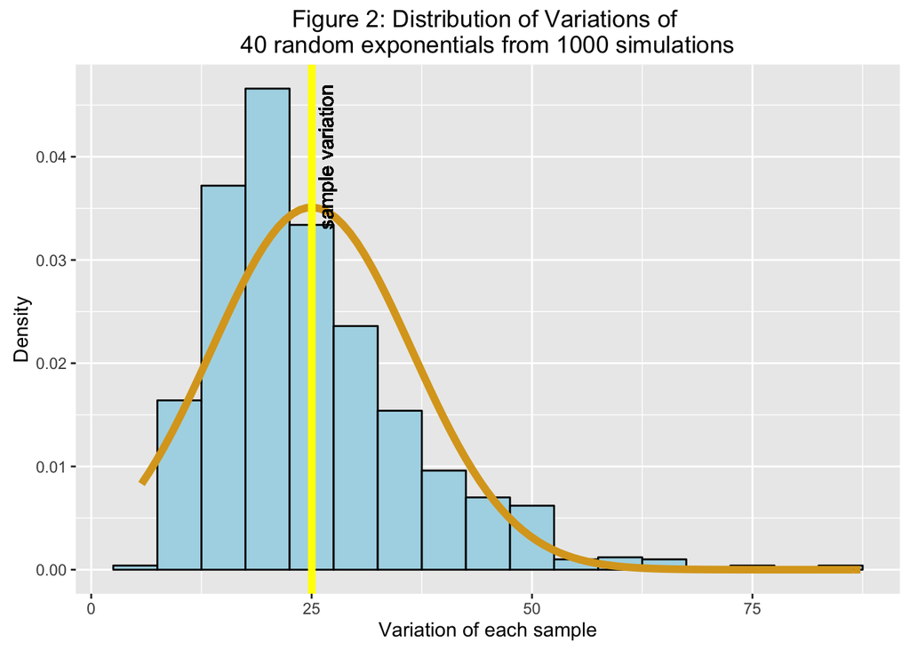

```r
vns <- data.frame(varz)
v <- ggplot(vns, aes(x = varz, fill=NULL)) + geom_histogram(aes(y=..density..), binwidth = 5, col = "black", fill = "light blue")
v <- v +  stat_function(fun=dnorm, args=list(mean = 25, sd = sd(varz)), colour = "goldenrod", size = 2)
v <- v + geom_vline(xintercept = mean(varz), colour = "yellow", size = 2, show.legend = TRUE)
v <- v + geom_text(aes(x = mean(varz), label = "\nsample variation", y= 0.04), angle = 90) +  xlab("Variation of each sample") +  ylab("Density") + ggtitle("Figure 2: Distribution of Variations of \n40 random exponentials from 1000 simulations")
 v
```

The goldenrod line is a theoretical normal density with mean of 25 and standard deviation of **11.3661229**, the measured standard deviation of the samples.

## Testing the hypothesis that the variance is 25

We can test the hypothesis that the mean of the simulated variances is 25 by using a t test. The p-value we get for the null hypothesis (mu = 25) is 0.964014 , which is a very convincing value to not reject the null hypothesis.

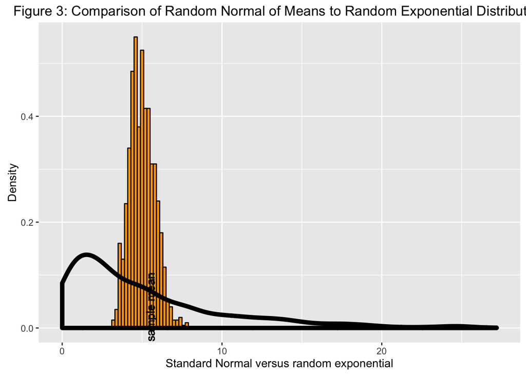

```r
h <- ggplot(mns, aes(x = meanz, fill=NULL)) + geom_histogram(aes(y=..density..), binwidth = 0.2, col = "black", fill = "orange")
h <- h + geom_density(aes(x=rexp(1000, 0.2)), size = 2, colour = "black")
h <- h + geom_text(aes(x = mean(meanz), label = "\nsample mean", y= 0.04), angle = 90) +  xlab("Standard Normal versus random exponential") +  ylab("Density") + ggtitle("Figure 3: Comparison of Random Normal of Means to Random Exponential Distribution")
h
```